# MLS KeeperIQ — R Statistical Report

Stability, rank disagreement, uncertainty, and New York Red Bulls trends

KeeperIQ analysis layer

2026-07-25

## Purpose

This report is the R analysis companion to the Python/TypeScript KeeperIQ product. It reads from the DuckDB relational database (`data/keeperiq.duckdb`) rather than re-implementing the scoring model. The goals are to:

1. quantify year-to-year stability of adjusted goalkeeper impact
2. contrast KeeperIQ ranks with traditional goals-allowed ranks
3. bootstrap match-level uncertainty for selected keepers
4. inspect component correlations
5. profile New York Red Bulls goalkeepers specifically

## Data pulled through SQL

```r
leaderboard <- DBI::dbGetQuery(con, "
  SELECT *
  FROM v_season_leaderboard
  ORDER BY season, rank_adjusted
") |> as_tibble()

components <- DBI::dbGetQuery(con, "
  SELECT *
  FROM v_component_matrix
") |> as_tibble()

disagreement <- DBI::dbGetQuery(con, "
  SELECT *
  FROM v_rank_disagreement
  WHERE season IN (2025, 2026)
") |> as_tibble()

match_form <- DBI::dbGetQuery(con, "
  SELECT *
  FROM v_match_form
  WHERE season IN (2025, 2026)
") |> as_tibble()

talent <- DBI::dbGetQuery(con, "
  SELECT *
  FROM v_talent_board
  ORDER BY talent_rank
") |> as_tibble()

red_bulls <- leaderboard |>
  filter(str_detect(tolower(coalesce(team_name, "")), "red bull") |
           team_abbreviation %in% c("NYRB", "RBNY"))

knitr::kable(
  leaderboard |>
    count(season, sample_status) |>
    pivot_wider(names_from = sample_status, values_from = n, values_fill = 0),
  caption = "Goalkeeper counts by season and sample status"
)
```

Goalkeeper counts by season and sample status

| season | limited | provisional | qualified |
| --- | --- | --- | --- |
| 2025 | 19 | 10 | 38 |
| 2026 | 15 | 3 | 30 |

## 1. Year-to-year stability

How stable is reliability-adjusted total G+/96 for keepers who appear in adjacent seasons with provisional-or-better minutes?

```r
stability <- yoy_stability(leaderboard)
stability |>
  gt() |>
  fmt_number(columns = spearman, decimals = 3) |>
  tab_header(
    title = "Spearman stability of adjusted total G+/96",
    subtitle = "Qualified and provisional goalkeepers only"
  )
```

Spearman stability of adjusted total G+/96

Qualified and provisional goalkeepers only

| season_pair | spearman | n |
| --- | --- | --- |
| 2025→2026 | 0.155 | 25 |

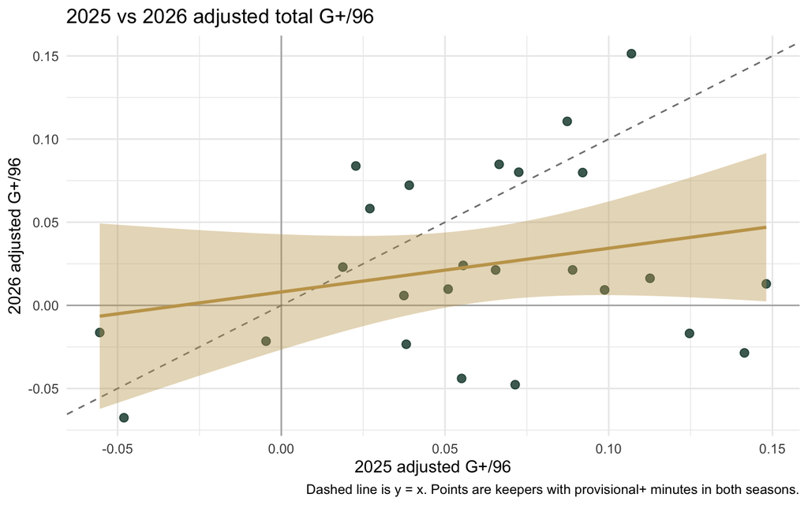

```r
shared <- leaderboard |>
  filter(sample_status %in% c("qualified", "provisional"), season %in% c(2025, 2026)) |>
  select(player_id, player_name, season, adjusted_total_p96) |>
  pivot_wider(names_from = season, values_from = adjusted_total_p96, names_prefix = "y") |>
  drop_na()

ggplot(shared, aes(x = y2025, y = y2026)) +
  geom_hline(yintercept = 0, colour = "grey70") +
  geom_vline(xintercept = 0, colour = "grey70") +
  geom_abline(slope = 1, intercept = 0, linetype = 2, colour = "grey50") +
  geom_point(alpha = 0.8, colour = "#0B3D2E", size = 2.5) +
  geom_smooth(method = "lm", se = TRUE, colour = "#C4A35A", fill = "#C4A35A33") +
  labs(
    title = "2025 vs 2026 adjusted total G+/96",
    x = "2025 adjusted G+/96",
    y = "2026 adjusted G+/96",
    caption = "Dashed line is y = x. Points are keepers with provisional+ minutes in both seasons."
  ) +
  theme_minimal(base_size = 12)
```

## 2. Goals-allowed rank versus KeeperIQ rank

A disagreement identifies goalkeepers whose context-adjusted evaluation differs from the traditional result. It does **not** automatically prove one metric is correct.

[figure not shown]

```r
ggplot(
  disagreement |> filter(season == 2025, !is.na(rank_disagreement)),
  aes(x = goals_allowed_rank, y = keeperiq_rank, colour = rank_disagreement)
) +
  geom_abline(slope = 1, intercept = 0, linetype = 2, colour = "grey60") +
  geom_point(size = 2.8, alpha = 0.9) +
  scale_colour_gradient2(low = "#B33A3A", mid = "grey70", high = "#1F7A4C") +
  scale_x_reverse() +
  scale_y_reverse() +
  labs(
    title = "2025: goals-allowed rank vs KeeperIQ rank",
    x = "Goals allowed rank (lower = fewer goals conceded / 96)",
    y = "KeeperIQ rank (lower = better)",
    colour = "Rank gap\n(GA rank − IQ rank)"
  ) +
  theme_minimal(base_size = 12)
```

```r
disagreement |>
  filter(season == 2025) |>
  mutate(abs_gap = abs(rank_disagreement)) |>
  slice_max(abs_gap, n = 12, with_ties = FALSE) |>
  select(
    player_name, team_abbreviation, keeperiq_rank, goals_allowed_rank,
    rank_disagreement, keeperiq, adjusted_total_p96, goals_conceded_p96, minutes
  ) |>
  gt() |>
  fmt_number(columns = c(keeperiq, adjusted_total_p96, goals_conceded_p96), decimals = 2) |>
  tab_header(title = "Largest 2025 rank disagreements")
```

Largest 2025 rank disagreements

| player_name | team_abbreviation | keeperiq_rank | goals_allowed_rank | rank_disagreement | keeperiq | adjusted_total_p96 | goals_conceded_p96 | minutes |
| --- | --- | --- | --- | --- | --- | --- | --- | --- |
| Zack Steffen | COL | 3 | 44 | 30 | 94.67 | 0.12 | 1.56 | 2332 |
| Evan Bush | CLB | 47 | 6 | -29 | 36.45 | 0.02 | 0.79 | 604 |
| Hugo Lloris | LAFC | 52 | 16 | -28 | 28.23 | 0.02 | 0.98 | 3537 |
| Stefan Frei | SEA | 55 | 19 | -27 | 22.68 | 0.01 | 1.08 | 2922 |
| Chris Brady | CHI | 17 | 51 | 25 | 68.52 | 0.07 | 1.66 | 2999 |
| Matt Turner | NER | 6 | 39 | 23 | 87.13 | 0.11 | 1.42 | 1012 |
| Kim Joon-Hong | DCU | 40 | 63 | 20 | 40.06 | 0.04 | 2.26 | 807 |
| Jeffrey Gal | CHI | 64 | 35 | -20 | 7.35 | −0.04 | 1.38 | 764 |
| James Pantemis | POR | 8 | 36 | 18 | 82.18 | 0.09 | 1.39 | 2340 |
| Roman Bürki | STL | 18 | 45 | 18 | 65.88 | 0.07 | 1.57 | 2567 |
| Jacob Jackson | FCD | 20 | 3 | -17 | 63.06 | 0.06 | 0.49 | 389 |
| Andrew Rick | PHI | 41 | 23 | -16 | 38.99 | 0.03 | 1.20 | 1443 |

## 3. Bootstrap uncertainty for selected keepers

Match-level nonparametric bootstrap of mean match G+/96 for high-minute 2026 keepers. This is an R-side uncertainty check complementary to the Python pipeline’s own bootstrap intervals.

```r
targets <- leaderboard |>
  filter(season == 2026, sample_status == "qualified") |>
  slice_min(rank_adjusted, n = 5, with_ties = FALSE)

boot_rows <- purrr::map_dfr(targets$player_name, function(name) {
  rates <- match_form |>
    filter(player_name == name, season == 2026) |>
    pull(ga_total_p96) |>
    purrr::discard(is.na)
  fit <- bootstrap_player_mean(rates, R = 1000L)
  tibble(
    player_name = name,
    n_matches = length(rates),
    mean_match_ga_p96 = fit$t0,
    low_90 = fit$conf[1],
    high_90 = fit$conf[2]
  )
})

boot_rows |>
  gt() |>
  fmt_number(columns = c(mean_match_ga_p96, low_90, high_90), decimals = 3) |>
  tab_header(
    title = "Bootstrap 90% intervals for mean match G+/96",
    subtitle = "Top five qualified 2026 goalkeepers by KeeperIQ rank"
  )
```

Bootstrap 90% intervals for mean match G+/96

Top five qualified 2026 goalkeepers by KeeperIQ rank

| player_name | n_matches | mean_match_ga_p96 | low_90 | high_90 |
| --- | --- | --- | --- | --- |
| Matt Turner | 15 | 0.623 | 0.230 | 1.030 |
| Brian Schwake | 16 | 0.480 | 0.276 | 0.699 |
| Brad Stuver | 16 | 0.319 | −0.025 | 0.655 |
| Chris Brady | 15 | 0.340 | −0.062 | 0.728 |
| Daniel | 16 | 0.290 | 0.073 | 0.526 |

## 4. Component correlations (2025)

```r
cmat <- component_cors(components, 2025)
cmat |>
  as.data.frame() |>
  rownames_to_column("component") |>
  gt() |>
  fmt_number(decimals = 2) |>
  tab_header(title = "Spearman correlations among adjusted component rates — 2025")
```

Spearman correlations among adjusted component rates — 2025

| component | fielding | passing | sweeping | claiming | handling | shot_stopping |
| --- | --- | --- | --- | --- | --- | --- |
| fielding | 1.00 | 0.31 | 0.28 | −0.17 | −0.07 | 0.13 |
| passing | 0.31 | 1.00 | 0.26 | 0.09 | 0.01 | 0.23 |
| sweeping | 0.28 | 0.26 | 1.00 | 0.06 | 0.05 | 0.09 |
| claiming | −0.17 | 0.09 | 0.06 | 1.00 | 0.14 | 0.33 |
| handling | −0.07 | 0.01 | 0.05 | 0.14 | 1.00 | −0.01 |
| shot_stopping | 0.13 | 0.23 | 0.09 | 0.33 | −0.01 | 1.00 |

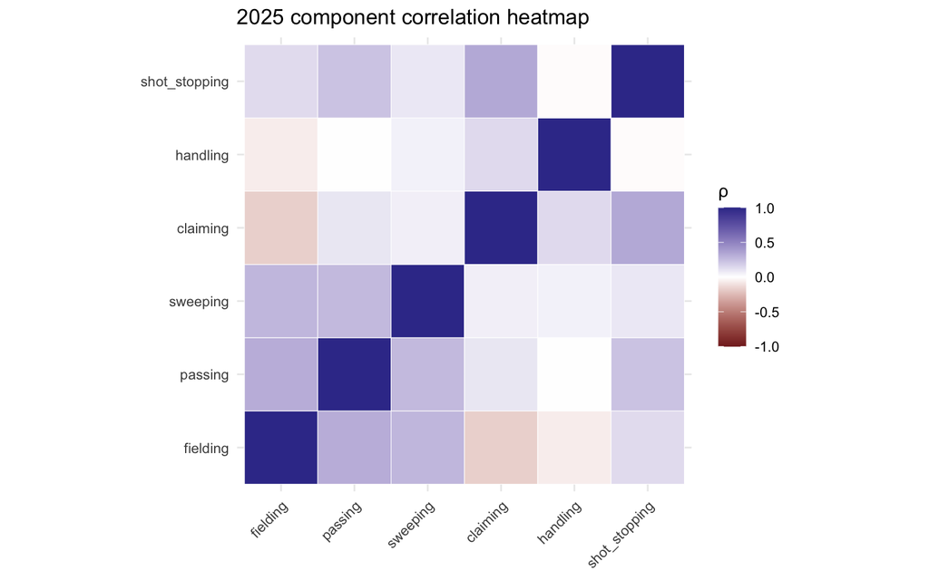

```r
cmat_df <- as.data.frame(as.table(cmat)) |>
  as_tibble() |>
  rename(component_a = Var1, component_b = Var2, rho = Freq)

ggplot(cmat_df, aes(component_a, component_b, fill = rho)) +
  geom_tile(colour = "white") +
  scale_fill_gradient2(limits = c(-1, 1), midpoint = 0) +
  coord_fixed() +
  labs(title = "2025 component correlation heatmap", x = NULL, y = NULL, fill = "ρ") +
  theme_minimal(base_size = 11) +
  theme(axis.text.x = element_text(angle = 45, hjust = 1))
```

## 5. New York Red Bulls goalkeeper trends

```r
red_bulls |>
  arrange(season, rank_adjusted) |>
  select(
    season, player_name, sample_status, minutes, keeperiq,
    adjusted_total_p96, observed_total_p96, goals_conceded_p96,
    save_pct, goals_prevented_p96, rank_adjusted, rank_disagreement, archetype_label
  ) |>
  gt() |>
  fmt_number(
    columns = c(keeperiq, adjusted_total_p96, observed_total_p96,
                goals_conceded_p96, save_pct, goals_prevented_p96),
    decimals = 2
  ) |>
  tab_header(title = "New York Red Bulls goalkeepers in KeeperIQ")
```

New York Red Bulls goalkeepers in KeeperIQ

| season | player_name | sample_status | minutes | keeperiq | adjusted_total_p96 | observed_total_p96 | goals_conceded_p96 | save_pct | goals_prevented_p96 | rank_adjusted | rank_disagreement | archetype_label |
| --- | --- | --- | --- | --- | --- | --- | --- | --- | --- | --- | --- | --- |
| 2025 | Carlos Coronel | qualified | 3145 | 92.08 | 0.12 | 0.26 | 1.22 | 71.22 | 0.25 | 4 | 13 | High-Volume Shot Stopper |
| 2025 | AJ Marcucci | limited | 207 | 56.01 | 0.04 | −0.08 | 0.93 | 60.00 | −0.15 | 27 | NA | NA |
| 2026 | Ethan Horvath | qualified | 1625 | 29.63 | 0.01 | −0.08 | 2.07 | 57.89 | −0.14 | 34 | 8 | High-Volume Shot Stopper |

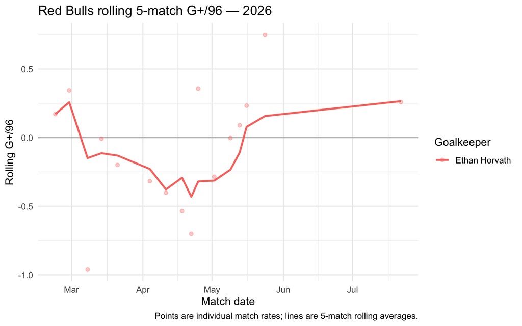

```r
rbn_names <- unique(red_bulls$player_name)
rbn_form <- match_form |>
  filter(player_name %in% rbn_names, season == 2026) |>
  arrange(date_utc)

if (nrow(rbn_form) > 0) {
  ggplot(rbn_form, aes(x = as.Date(date_utc), y = rolling_5_match_ga_p96, colour = player_name)) +
    geom_hline(yintercept = 0, colour = "grey70") +
    geom_line(linewidth = 1) +
    geom_point(aes(y = ga_total_p96), alpha = 0.35) +
    labs(
      title = "Red Bulls rolling 5-match G+/96 — 2026",
      x = "Match date",
      y = "Rolling G+/96",
      colour = "Goalkeeper",
      caption = "Points are individual match rates; lines are 5-match rolling averages."
    ) +
    theme_minimal(base_size = 12)
} else {
  cat("No 2026 Red Bulls match-form rows available in the current database extract.")
}
```

## 6. Current-talent weights for Red Bulls keepers

```r
talent |>
  filter(player_name %in% rbn_names) |>
  select(
    talent_rank, player_name, keeperiq_talent, talent_total_p96,
    weight_league_prior, weight_prior_season, weight_live_season,
    prior_season_minutes, live_season_minutes, prior_source
  ) |>
  gt() |>
  fmt_number(columns = c(keeperiq_talent, talent_total_p96), decimals = 2) |>
  fmt_percent(
    columns = c(weight_league_prior, weight_prior_season, weight_live_season),
    decimals = 1
  ) |>
  tab_header(title = "Current-talent blend — Red Bulls goalkeepers")
```

Current-talent blend — Red Bulls goalkeepers

| talent_rank | player_name | keeperiq_talent | talent_total_p96 | weight_league_prior | weight_prior_season | weight_live_season | prior_season_minutes | live_season_minutes | prior_source |
| --- | --- | --- | --- | --- | --- | --- | --- | --- | --- |
| 3 | Carlos Coronel | 96.70 | 0.13 | 65.1% | 34.9% | 0.0% | 3145 | 0 | prior_season_available |
| 35 | AJ Marcucci | 38.98 | 0.04 | 93.5% | 6.5% | 0.0% | 207 | 0 | prior_season_available |
| 53 | Ethan Horvath | 24.99 | 0.03 | 80.5% | 0.0% | 19.5% | 0 | 1625 | no_prior_season |

## Limitations

- Goals Added is itself a model estimate from American Soccer Analysis.
- R bootstraps here use match-level mean G+/96 and are complementary to, not identical with, the Python pipeline’s shrinkage-aware bootstrap.
- Roster affiliation in the leaderboard view reflects ASA season team ids; mid-season transfers can complicate club labels.
- Small samples remain noisy even after reliability adjustment.